# Advanced Bioinformatics 2022 Assessment

21134573

03/05/2022

### Task 3.1

#### Using the sum() function and : operator, write an expression in the code snippet to evaluate the sum of all integers between 5 and 55. (5pt)

```r
#Pass a vector 5-55 to sum, to add the elements together.
sum(5:55)
```

```
## [1] 1530
```

### Task 3.2

#### Write a function called sumfun with one input parameter, called n, that calculates the sum of all integers between 5 and n. Use the function to do the calculation for n = 10, n = 20, and n = 100 and present the results. (5pt)

```r
#function called sumfun that takes n and passes a vector 5:n and then tested with 3 calculations inputs
sumfun <- function(n)
  sum(5:n)

sumfun(10)
```

```
## [1] 45
```

```r
sumfun(20)
```

```
## [1] 200
```

```r
sumfun(100)
```

```
## [1] 5040
```

### Task 3.3

#### The famous Fibonacci series is calculated as the sum of the two preceding members of the sequence, where the first two steps in the sequence are 1, 1. Write an R script using a for loop to calculate and print out the first 12 entries of the Fibonacci series. (5pt)

```r
#fibonacci <- interpret length as numbers(12)
#for fibonacci positions [1] + [2] = 1
#for fibonacci positions 3:12 = take sum of two position values before a (a-2 positions, a-1 position)
fibonacci <- numeric(12)
fibonacci[1] <- fibonacci[2] <- 1
for (a in 3:12) fibonacci[a] <- fibonacci[a - 2] + fibonacci[a - 1]
print(fibonacci)
```

```
##  [1]   1   1   2   3   5   8  13  21  34  55  89 144
```

### Task 3.4

#### With the mtcars dataset bundled with R, use ggplot to generate a box of miles per gallon (in the variable mpg) as a function of the number of gears (in the variable gear). Use the fill aesthetic to colour bars by number of gears. (5pt)

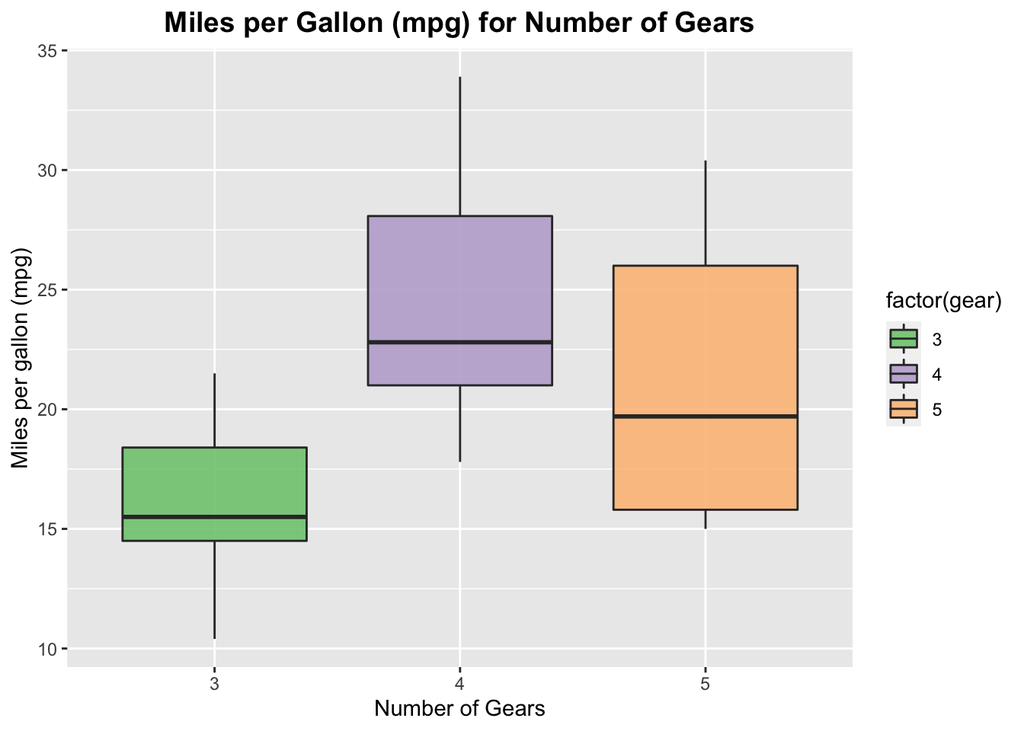

```r
library(ggplot2)
data(mtcars)

ggplot(mtcars, aes(x= as.factor(gear), y=mpg, fill = factor(gear))) +
  geom_boxplot(alpha=0.9) +
  labs(
    title = "Miles per Gallon (mpg) for Number of Gears",
    x = "Number of Gears",
    y = "Miles per gallon (mpg)") +
  theme(plot.title = element_text(size = 14, face = "bold", hjust = 0.5)) +
  scale_fill_brewer(palette="Accent")
```